# Reproducible Research - Course Project 1

Ian Chua

9/1/2019

# Loading in data

The following chunk of code loads the required libraries, reads in the activity data, and converts the variables into the appropriate format.

```r
library(tidyverse)
library(lubridate)
data <- read.csv(file = "activity.csv")
data$date <- as.Date(data$date)
data <- tbl_df(data)
```

# 1. What is mean total number of steps taken per day?

The dataset is first grouped by “date”, and the total number of steps taken per day is calculated. Following which, a histogram is plot based on the total number of steps taken.

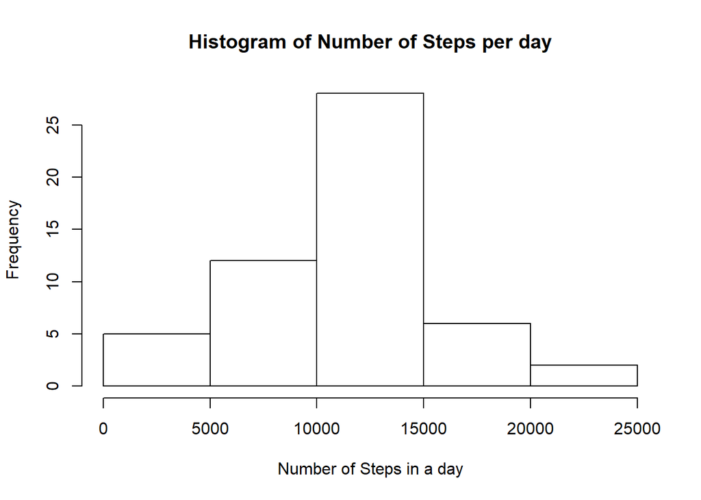

```r
bydate <- group_by(data,date)
summarised <- summarise_all(bydate,sum)
hist(summarised$steps, xlab = "Number of Steps in a day", main = "Histogram of Number of Steps per day")
```

The mean (10,766.19) and median (10,765) total steps per day is calculated.

```r
mean(summarised$steps, na.rm = TRUE)
```

```
## [1] 10766.19
```

```r
median(summarised$steps, na.rm = TRUE)
```

```
## [1] 10765
```

# 2. What is the average daily activity pattern?

The dataset is first groupd by “interval”, and the average number of steps taken per interval is calculated. A time series plot is then done on Steps against Time.

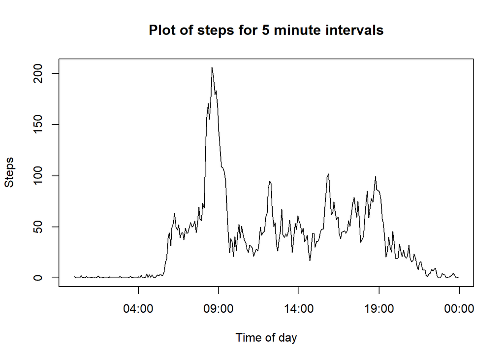

```r
byinterval <- group_by(data,interval)
byinterval$time <- as.POSIXct(sprintf("%04d.00", byinterval$interval), format="%H%M")
summarised2 <- summarise_all(byinterval, mean, na.rm = TRUE)
plot(x=summarised2$time, y=summarised2$steps, type = "l", xlab = "Time of day", ylab = "Steps", main = "Plot of steps for 5 minute intervals")
```

The max number of steps in a given 5 minute interval is 206. The corresponding time is 8:35am.

```r
max(summarised2$steps)
```

```
## [1] 206.1698
```

```r
summarised2$interval[which.max(summarised2$steps)]
```

```
## [1] 835
```

# 3. Imputing missing values

To find out how many NA values are there, the is.na function is called on the individual variables, with a sum function. It appears that there are 2,304 NA values for steps, and 0 NA values for date and interval.

```r
apply(apply(data,2,is.na),2,sum)
```

```
##    steps     date interval
##     2304        0        0
```

A glance at the dataset reveals that there are days where not a single value of steps taken is recorded. Hence, a strategy of using the mean at each 5-minute interval is used.

```r
imputed <- left_join(data,summarised2[,1:2],by = "interval")
names(imputed) <- c("steps","date","interval","meansteps")
imputed$steps[is.na(imputed$steps)] <- imputed$meansteps[is.na(imputed$steps)]
print(imputed)
```

```
## # A tibble: 17,568 x 4
##     steps date       interval meansteps
##     <dbl> <date>        <int>     <dbl>
##  1 1.72   2012-10-01        0    1.72
##  2 0.340  2012-10-01        5    0.340
##  3 0.132  2012-10-01       10    0.132
##  4 0.151  2012-10-01       15    0.151
##  5 0.0755 2012-10-01       20    0.0755
##  6 2.09   2012-10-01       25    2.09
##  7 0.528  2012-10-01       30    0.528
##  8 0.868  2012-10-01       35    0.868
##  9 0      2012-10-01       40    0
## 10 1.47   2012-10-01       45    1.47
## # ... with 17,558 more rows
```

```r
groupimputed <- group_by(imputed,date)
```

After imputing the missing data, a histogram is plotted for the total number of steps in a day.

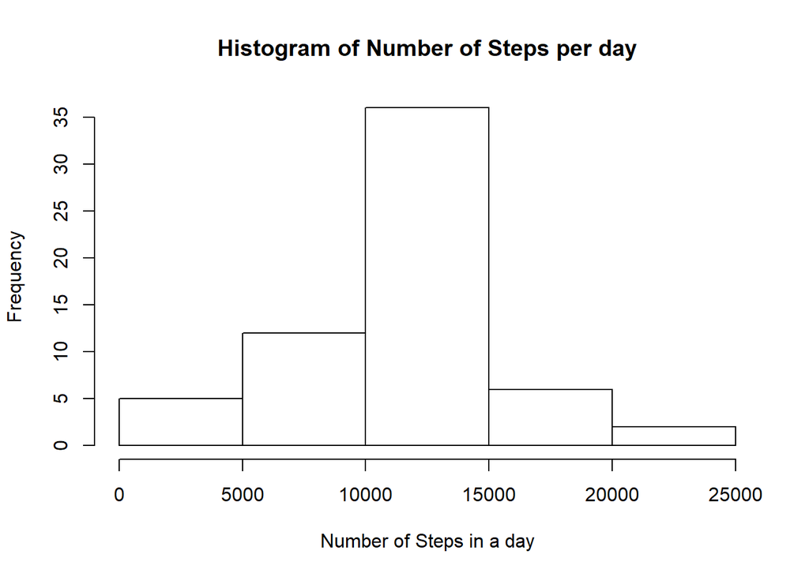

```r
summarised3 <- summarise_all(groupimputed,sum)
hist(summarised3$steps, xlab = "Number of Steps in a day", main = "Histogram of Number of Steps per day")
```

The mean and median of the new dataset is calculated. Compared with the dataset with missing values, only the median changed, which is now 10766.19, same as the mean.

```r
mean(summarised3$steps, na.rm = TRUE)
```

```
## [1] 10766.19
```

```r
median(summarised3$steps, na.rm = TRUE)
```

```
## [1] 10766.19
```

# 4. Are there differences in activity patterns between weekdays and weekends?

A separate column is created to track the day of the week, which is then converted to either a weekday or a weekend.

```r
imputed$dayofweek <- wday(imputed$date, week_start = getOption("lubridate.week.start",1))
imputed$dayofweek[imputed$dayofweek>5] <- as.character("Weekend")
imputed$dayofweek[imputed$dayofweek<6] <- as.character("Weekday")
imputed$dayofweek <- as.factor(imputed$dayofweek)
print(imputed)
```

```
## # A tibble: 17,568 x 5
##     steps date       interval meansteps dayofweek
##     <dbl> <date>        <int>     <dbl> <fct>
##  1 1.72   2012-10-01        0    1.72   Weekday
##  2 0.340  2012-10-01        5    0.340  Weekday
##  3 0.132  2012-10-01       10    0.132  Weekday
##  4 0.151  2012-10-01       15    0.151  Weekday
##  5 0.0755 2012-10-01       20    0.0755 Weekday
##  6 2.09   2012-10-01       25    2.09   Weekday
##  7 0.528  2012-10-01       30    0.528  Weekday
##  8 0.868  2012-10-01       35    0.868  Weekday
##  9 0      2012-10-01       40    0      Weekday
## 10 1.47   2012-10-01       45    1.47   Weekday
## # ... with 17,558 more rows
```

The dataset is grouped by Interval and Day Of Week, then irrelevant variables are dropped.The mean of each weekday/weekend - interval pairing is then computed

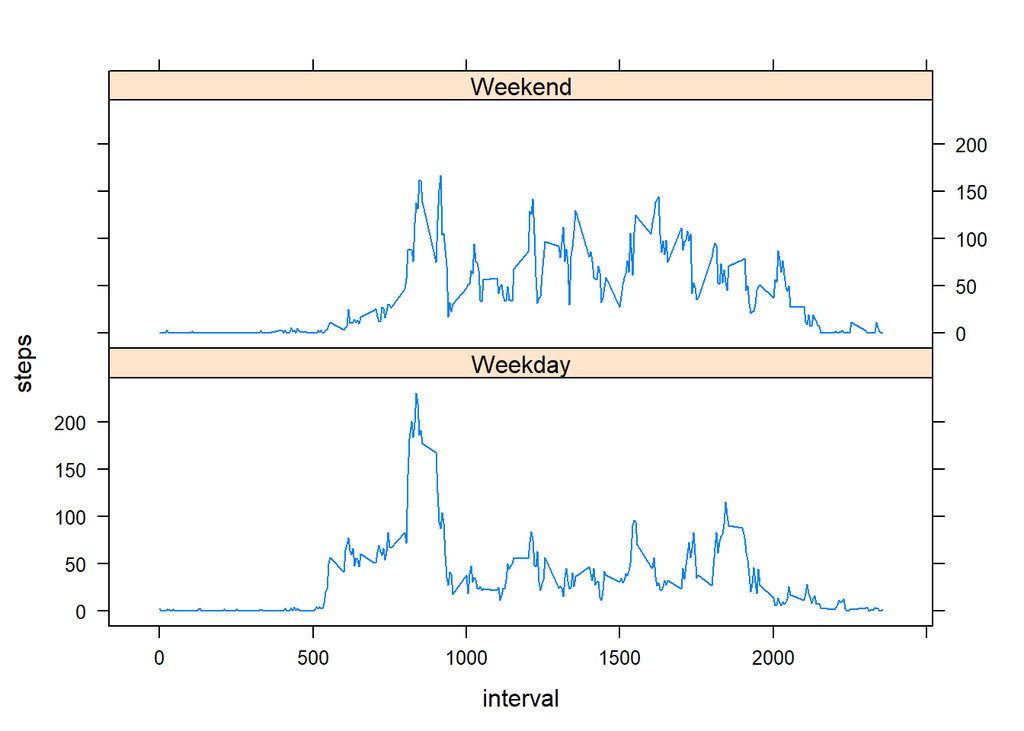

```r
imputed <- group_by(imputed,interval,dayofweek)
imputed <- imputed[,c(1,3,5)]
imputed <- summarise_all(imputed,mean)
library(lattice)
with(imputed,xyplot(steps~interval|dayofweek, layout=c(1,2),type = "l"))
```

Based on the above, it seems that the individual has more varied steps over the weekends, but on weekdays the individual seems to clock a higher activity rate at around 8 to 9 am in the morning.